# PERSONAL LOAN CAMPAIGN PROJECT

### Using Sequential Feature Selector to reduce the model dimension

```python
# Let's import the right library for the task
from mlxtend.feature_selection import SequentialFeatureSelector as SFS

# to plot the performance with addition of each feature
from mlxtend.plotting import plot_sequential_feature_selection as plot_sfs
```

```python
#  Let's fit the model on train set
model = LogisticRegression(solver="newton-cg", n_jobs=-1, random_state=1, max_iter=100)
```

```python
# we will first build model with all variables
sfs = SFS(
    model,
    k_features=49,
    forward=True,
    floating=False,
    scoring="f1",
    verbose=2,
    cv=3,
    n_jobs=-1,
)

sfs = sfs.fit(X_train, y_train)
```

```
[Parallel(n_jobs=-1)]: Using backend LokyBackend with 4 concurrent workers.
[Parallel(n_jobs=-1)]: Done  33 tasks      | elapsed:    5.9s
[Parallel(n_jobs=-1)]: Done  49 out of  49 | elapsed:    7.3s finished

[2021-10-27 16:39:09] Features: 1/49 -- score: 0.41343889085824576[Parallel(n_jobs=-1)]: Using backend LokyBackend with 4 concurrent workers.
[Parallel(n_jobs=-1)]: Done  33 tasks      | elapsed:    3.2s
[Parallel(n_jobs=-1)]: Done  48 out of  48 | elapsed:    4.7s finished

[2021-10-27 16:39:14] Features: 2/49 -- score: 0.5343065333269479[Parallel(n_jobs=-1)]: Using backend LokyBackend with 4 concurrent workers.
[Parallel(n_jobs=-1)]: Done  33 tasks      | elapsed:    4.4s
[Parallel(n_jobs=-1)]: Done  47 out of  47 | elapsed:    6.1s finished

[2021-10-27 16:39:20] Features: 3/49 -- score: 0.588710257767378[Parallel(n_jobs=-1)]: Using backend LokyBackend with 4 concurrent workers.
[Parallel(n_jobs=-1)]: Done  33 tasks      | elapsed:    4.7s
[Parallel(n_jobs=-1)]: Done  46 out of  46 | elapsed:    6.2s finished

[2021-10-27 16:39:26] Features: 4/49 -- score: 0.7247668393782384[Parallel(n_jobs=-1)]: Using backend LokyBackend with 4 concurrent workers.
[Parallel(n_jobs=-1)]: Done  33 tasks      | elapsed:    4.4s
[Parallel(n_jobs=-1)]: Done  45 out of  45 | elapsed:    6.0s finished

[2021-10-27 16:39:33] Features: 5/49 -- score: 0.754399957882545[Parallel(n_jobs=-1)]: Using backend LokyBackend with 4 concurrent workers.
[Parallel(n_jobs=-1)]: Done  33 tasks      | elapsed:    4.3s
[Parallel(n_jobs=-1)]: Done  44 out of  44 | elapsed:    5.7s finished

[2021-10-27 16:39:38] Features: 6/49 -- score: 0.7617423782550928[Parallel(n_jobs=-1)]: Using backend LokyBackend with 4 concurrent workers.
[Parallel(n_jobs=-1)]: Done  33 tasks      | elapsed:    4.1s
[Parallel(n_jobs=-1)]: Done  43 out of  43 | elapsed:    5.2s finished

[2021-10-27 16:39:44] Features: 7/49 -- score: 0.7700280600422317[Parallel(n_jobs=-1)]: Using backend LokyBackend with 4 concurrent workers.
[Parallel(n_jobs=-1)]: Done  33 tasks      | elapsed:    4.0s
[Parallel(n_jobs=-1)]: Done  42 out of  42 | elapsed:    5.1s finished

[2021-10-27 16:39:49] Features: 8/49 -- score: 0.7778887121016439[Parallel(n_jobs=-1)]: Using backend LokyBackend with 4 concurrent workers.
[Parallel(n_jobs=-1)]: Done  33 tasks      | elapsed:    4.4s
[Parallel(n_jobs=-1)]: Done  41 out of  41 | elapsed:    5.3s finished

[2021-10-27 16:39:54] Features: 9/49 -- score: 0.7779287439613527[Parallel(n_jobs=-1)]: Using backend LokyBackend with 4 concurrent workers.
[Parallel(n_jobs=-1)]: Done  33 tasks      | elapsed:    4.1s
[Parallel(n_jobs=-1)]: Done  40 out of  40 | elapsed:    4.9s finished

```

[output cut: 109 more lines]

```
[Parallel(n_jobs=-1)]: Done   5 out of   5 | elapsed:    1.4s finished

[2021-10-27 16:42:12] Features: 45/49 -- score: 0.7582399835906681[Parallel(n_jobs=-1)]: Using backend LokyBackend with 4 concurrent workers.
[Parallel(n_jobs=-1)]: Done   4 out of   4 | elapsed:    1.0s finished

[2021-10-27 16:42:13] Features: 46/49 -- score: 0.7532530961102389[Parallel(n_jobs=-1)]: Using backend LokyBackend with 4 concurrent workers.
[Parallel(n_jobs=-1)]: Done   3 out of   3 | elapsed:    0.9s finished

[2021-10-27 16:42:14] Features: 47/49 -- score: 0.754557175764834[Parallel(n_jobs=-1)]: Using backend LokyBackend with 4 concurrent workers.
[Parallel(n_jobs=-1)]: Done   2 out of   2 | elapsed:    0.7s finished

[2021-10-27 16:42:15] Features: 48/49 -- score: 0.7443312240213412[Parallel(n_jobs=-1)]: Using backend LokyBackend with 4 concurrent workers.
[Parallel(n_jobs=-1)]: Done   1 out of   1 | elapsed:    0.6s finished

[2021-10-27 16:42:16] Features: 49/49 -- score: 0.7534433097669546
```

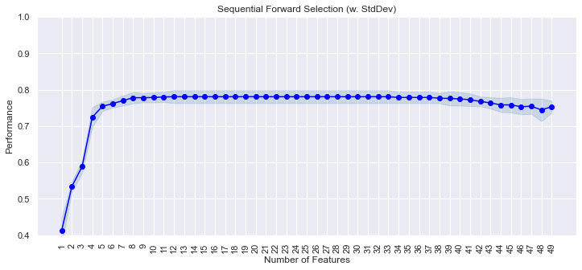

```python
# Let's plot the graph depicting performance/value addition of each variable in the model
fig1 = plot_sfs(sfs.get_metric_dict(), kind="std_dev", figsize=(12, 5))
plt.ylim([0.4, 1])
plt.title("Sequential Forward Selection (w. StdDev)")
plt.xticks(rotation=90)
plt.show()
```

- We can see that performance increases till the 12th feature and then became constant before even dropping after the 40th feature.
- So we'll use 12 features only to build our model

```
[Parallel(n_jobs=-1)]: Using backend LokyBackend with 4 concurrent workers.
[Parallel(n_jobs=-1)]: Done  33 tasks      | elapsed:    3.0s
[Parallel(n_jobs=-1)]: Done  49 out of  49 | elapsed:    4.4s finished

[2021-10-27 16:42:21] Features: 1/12 -- score: 0.41343889085824576[Parallel(n_jobs=-1)]: Using backend LokyBackend with 4 concurrent workers.
[Parallel(n_jobs=-1)]: Done  33 tasks      | elapsed:    3.3s
[Parallel(n_jobs=-1)]: Done  48 out of  48 | elapsed:    4.7s finished

[2021-10-27 16:42:26] Features: 2/12 -- score: 0.5343065333269479[Parallel(n_jobs=-1)]: Using backend LokyBackend with 4 concurrent workers.
[Parallel(n_jobs=-1)]: Done  33 tasks      | elapsed:    4.2s
[Parallel(n_jobs=-1)]: Done  47 out of  47 | elapsed:    6.0s finished

[2021-10-27 16:42:32] Features: 3/12 -- score: 0.588710257767378[Parallel(n_jobs=-1)]: Using backend LokyBackend with 4 concurrent workers.
[Parallel(n_jobs=-1)]: Done  33 tasks      | elapsed:    4.2s
[Parallel(n_jobs=-1)]: Done  46 out of  46 | elapsed:    5.9s finished

[2021-10-27 16:42:38] Features: 4/12 -- score: 0.7247668393782384[Parallel(n_jobs=-1)]: Using backend LokyBackend with 4 concurrent workers.
[Parallel(n_jobs=-1)]: Done  33 tasks      | elapsed:    4.5s
[Parallel(n_jobs=-1)]: Done  45 out of  45 | elapsed:    6.0s finished

[2021-10-27 16:42:44] Features: 5/12 -- score: 0.754399957882545[Parallel(n_jobs=-1)]: Using backend LokyBackend with 4 concurrent workers.
[Parallel(n_jobs=-1)]: Done  33 tasks      | elapsed:    4.2s
[Parallel(n_jobs=-1)]: Done  44 out of  44 | elapsed:    5.7s finished

[2021-10-27 16:42:50] Features: 6/12 -- score: 0.7617423782550928[Parallel(n_jobs=-1)]: Using backend LokyBackend with 4 concurrent workers.
[Parallel(n_jobs=-1)]: Done  33 tasks      | elapsed:    4.2s
[Parallel(n_jobs=-1)]: Done  43 out of  43 | elapsed:    5.3s finished

[2021-10-27 16:42:55] Features: 7/12 -- score: 0.7700280600422317[Parallel(n_jobs=-1)]: Using backend LokyBackend with 4 concurrent workers.
[Parallel(n_jobs=-1)]: Done  33 tasks      | elapsed:    4.2s
[Parallel(n_jobs=-1)]: Done  42 out of  42 | elapsed:    5.1s finished

[2021-10-27 16:43:01] Features: 8/12 -- score: 0.7778887121016439[Parallel(n_jobs=-1)]: Using backend LokyBackend with 4 concurrent workers.
[Parallel(n_jobs=-1)]: Done  33 tasks      | elapsed:    4.2s
[Parallel(n_jobs=-1)]: Done  41 out of  41 | elapsed:    5.2s finished

[2021-10-27 16:43:06] Features: 9/12 -- score: 0.7779287439613527[Parallel(n_jobs=-1)]: Using backend LokyBackend with 4 concurrent workers.
[Parallel(n_jobs=-1)]: Done  33 tasks      | elapsed:    4.5s
[Parallel(n_jobs=-1)]: Done  40 out of  40 | elapsed:    5.3s finished

[2021-10-27 16:43:11] Features: 10/12 -- score: 0.7786446660690273[Parallel(n_jobs=-1)]: Using backend LokyBackend with 4 concurrent workers.
[Parallel(n_jobs=-1)]: Done  39 out of  39 | elapsed:    5.3s finished

[2021-10-27 16:43:17] Features: 11/12 -- score: 0.7800081041144025[Parallel(n_jobs=-1)]: Using backend LokyBackend with 4 concurrent workers.
[Parallel(n_jobs=-1)]: Done  38 out of  38 | elapsed:    5.1s finished

[2021-10-27 16:43:22] Features: 12/12 -- score: 0.7806990236309609
```

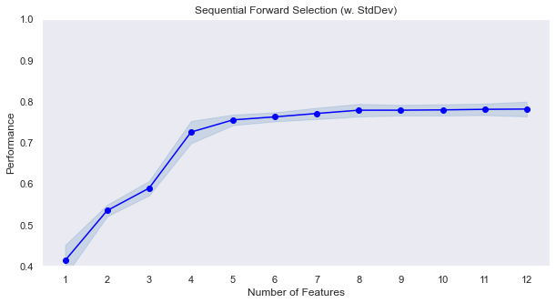

```python
# Let's build the model with just 12 features
sfs1 = SFS(
    model,
    k_features=12,
    forward=True,
    floating=False,
    scoring="f1",
    verbose=2,
    cv=3,
    n_jobs=-1,
)

sfs1 = sfs1.fit(X_train, y_train)

fig1 = plot_sfs(sfs1.get_metric_dict(), kind="std_dev", figsize=(10, 5))

plt.ylim([0.4, 1])
plt.title("Sequential Forward Selection (w. StdDev)")
plt.grid()
plt.show()
```

```python
# Finding the 12 features that are important
feat_cols = list(sfs1.k_feature_idx_)
print(feat_cols)
```

```
[1, 2, 5, 6, 7, 9, 10, 12, 17, 35, 36, 48]
```

```python
X_train.columns[feat_cols]  # To identify the names of the 12 important features
```

```
Index(['Income', 'Family', 'Securities_Account', 'CD_Account', 'Online',
       'Education_2', 'Education_3', 'county_Contra Costa ', 'county_Kern ',
       'county_San Mateo ', 'county_Santa Barbara ', 'county_Yolo '],
      dtype='object')
```

```python
X_train_final = X_train[
    X_train.columns[feat_cols]
]  # Let's create a new train set with the 12 features

# Creating new x_test with the 12 same variables that we selected for x_train
X_test_final = X_test[X_train_final.columns]
```

```python
# Fitting logistic regession model on the new train set created above

logreg = LogisticRegression(
    solver="newton-cg", penalty="none", verbose=True, n_jobs=-1, random_state=0
)

logreg.fit(X_train_final, y_train)
```

```
[Parallel(n_jobs=-1)]: Using backend LokyBackend with 4 concurrent workers.
[Parallel(n_jobs=-1)]: Done   1 out of   1 | elapsed:    0.0s finished
```

```
LogisticRegression(C=1.0, class_weight=None, dual=False, fit_intercept=True,
                   intercept_scaling=1, l1_ratio=None, max_iter=100,
                   multi_class='auto', n_jobs=-1, penalty='none',
                   random_state=0, solver='newton-cg', tol=0.0001, verbose=True,
                   warm_start=False)
```

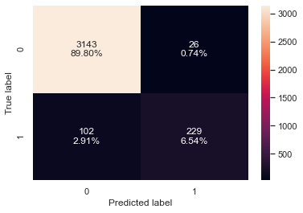

```python
##let's look at the model performance
confusion_matrix_sklearn_with_threshold(logreg, X_train_final, y_train)  # on train set
```

```python
# Let's print the model performance on the train set
log_reg_model_train_perf_SFS = model_performance_classification_sklearn_with_threshold(
    logreg, X_train_final, y_train
)
print("Training performance:")
log_reg_model_train_perf_SFS
```

```
Training performance:
```

|  | Accuracy | Recall | Precision | F1 |
| --- | --- | --- | --- | --- |
| 0 | 0.963429 | 0.691843 | 0.898039 | 0.78157 |

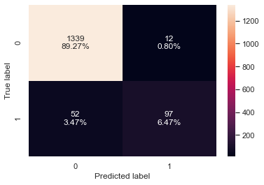

```python
# Let's create confusion matrix on the test set
confusion_matrix_sklearn_with_threshold(logreg, X_test_final, y_test)  # on test set
```

```python
# Let's print the model performance on the test set
log_reg_model_test_perf_SFS_ = model_performance_classification_sklearn_with_threshold(
    logreg, X_test_final, y_test
)
print("Test set performance:")
log_reg_model_test_perf_SFS_
```

```
Test set performance:
```

|  | Accuracy | Recall | Precision | F1 |
| --- | --- | --- | --- | --- |
| 0 | 0.957333 | 0.651007 | 0.889908 | 0.751938 |

- Model is giving a generalized performance on training and test set.
- With a fewer number of features, the model performance is comparable to the initial logistic regression model.

### Model Performance Summary

```python
# training performance comparison

models_train_comp_df = pd.concat(
    [
        log_reg_model_train_perf.T,
        log_reg_model_train_perf_threshold_auc_roc.T,
        log_reg_model_train_perf_threshold_curve.T,
        log_reg_model_train_perf_SFS.T,
    ],
    axis=1,
)
models_train_comp_df.columns = [
    "Logistic Regression sklearn",
    "Logistic Regression-0.07 Threshold",
    "Logistic Regression-0.35 Threshold",
    "Logistic Regression - SFS",
]
print("Training performance comparison:")
models_train_comp_df
```

```
Training performance comparison:
```

|  | Logistic Regression sklearn | Logistic Regression-0.07 Threshold | Logistic Regression-0.35 Threshold | Logistic Regression - SFS |
| --- | --- | --- | --- | --- |
| Accuracy | 0.963429 | 0.888286 | 0.961143 | 0.963429 |
| Recall | 0.691843 | 0.930514 | 0.791541 | 0.691843 |
| Precision | 0.898039 | 0.455621 | 0.796353 | 0.898039 |
| F1 | 0.781570 | 0.611718 | 0.793939 | 0.781570 |

```python
# testing performance comparison

models_test_comp_df = pd.concat(
    [
        log_reg_model_test_perf.T,
        log_reg_model_test_perf_threshold_auc_roc.T,
        log_reg_model_test_perf_threshold_curve.T,
        log_reg_model_test_perf_SFS_.T,
    ],
    axis=1,
)
models_test_comp_df.columns = [
    "Logistic Regression sklearn",
    "Logistic Regression-0.07 Threshold",
    "Logistic Regression-0.35 Threshold",
    "Logistic Regression - SFS",
]
print("Test set performance comparison:")
models_test_comp_df
```

```
Test set performance comparison:
```

|  | Logistic Regression sklearn | Logistic Regression-0.07 Threshold | Logistic Regression-0.35 Threshold | Logistic Regression - SFS |
| --- | --- | --- | --- | --- |
| Accuracy | 0.958667 | 0.893333 | 0.956667 | 0.957333 |
| Recall | 0.644295 | 0.906040 | 0.731544 | 0.651007 |
| Precision | 0.914286 | 0.480427 | 0.813433 | 0.889908 |
| F1 | 0.755906 | 0.627907 | 0.770318 | 0.751938 |

### Conclusion

- We built a model which has the same F1 score as the initial model but with only 12 features.
- We found that 'Income', 'Family', 'Securities_Account', 'CD_Account', 'Online','Education_2', 'Education_3', 'county_Contra Costa ', 'county_Kern ','county_San Mateo ', 'county_Santa Barbara ', and 'county_Yolo 'are the most significant features determining whether a customer will take personal loan or not.

## Decision Tree Method

#### Let's built another model using the decision tree method

```python
df_new.head()  # let's see the first 5 rows of the earlier copied data set
```

|  | Age | Experience | Income | Family | CCAvg | Education | Mortgage | Personal_Loan | Securities_Account | CD_Account | Online | CreditCard | county |
| --- | --- | --- | --- | --- | --- | --- | --- | --- | --- | --- | --- | --- | --- |
| 0 | 25 | 1 | 49 | 4 | 1.6 | 1 | 0 | 0 | 1 | 0 | 0 | 0 | Los Angeles |
| 1 | 45 | 19 | 34 | 3 | 1.5 | 1 | 0 | 0 | 1 | 0 | 0 | 0 | Los Angeles |
| 2 | 39 | 15 | 11 | 1 | 1.0 | 1 | 0 | 0 | 0 | 0 | 0 | 0 | Alameda |
| 3 | 35 | 9 | 100 | 1 | 2.7 | 2 | 0 | 0 | 0 | 0 | 0 | 0 | San Francisco |
| 4 | 35 | 8 | 45 | 4 | 1.0 | 2 | 0 | 0 | 0 | 0 | 0 | 1 | Los Angeles |

```python
df_new.shape  # checking the number of rows and columns
```

```
(5000, 13)
```

#### Observation: The data set contains 5000 rows and 13 columns

```python
Data = pd.get_dummies(df_new)  # To create dummy features on the data set
Data.head()  # to display the first 5 rows in the data set
```

|  | Age | Experience | Income | Family | CCAvg | Education | Mortgage | Personal_Loan | Securities_Account | CD_Account | Online | CreditCard | county_Alameda | county_Butte | county_Contra Costa | county_El Dorado | county_Fresno | county_Humboldt | county_Imperial | county_Kern | county_Lake | county_Los Angeles | county_Marin | county_Mendocino | county_Merced | county_Monterey | county_Napa | county_Orange | county_Placer | … |
| --- | --- | --- | --- | --- | --- | --- | --- | --- | --- | --- | --- | --- | --- | --- | --- | --- | --- | --- | --- | --- | --- | --- | --- | --- | --- | --- | --- | --- | --- | --- |
| 0 | 25 | 1 | 49 | 4 | 1.6 | 1 | 0 | 0 | 1 | 0 | 0 | 0 | 0 | 0 | 0 | 0 | 0 | 0 | 0 | 0 | 0 | 1 | 0 | 0 | 0 | 0 | 0 | 0 | 0 | … |
| 1 | 45 | 19 | 34 | 3 | 1.5 | 1 | 0 | 0 | 1 | 0 | 0 | 0 | 0 | 0 | 0 | 0 | 0 | 0 | 0 | 0 | 0 | 1 | 0 | 0 | 0 | 0 | 0 | 0 | 0 | … |
| 2 | 39 | 15 | 11 | 1 | 1.0 | 1 | 0 | 0 | 0 | 0 | 0 | 0 | 1 | 0 | 0 | 0 | 0 | 0 | 0 | 0 | 0 | 0 | 0 | 0 | 0 | 0 | 0 | 0 | 0 | … |
| 3 | 35 | 9 | 100 | 1 | 2.7 | 2 | 0 | 0 | 0 | 0 | 0 | 0 | 0 | 0 | 0 | 0 | 0 | 0 | 0 | 0 | 0 | 0 | 0 | 0 | 0 | 0 | 0 | 0 | 0 | … |
| 4 | 35 | 8 | 45 | 4 | 1.0 | 2 | 0 | 0 | 0 | 0 | 0 | 1 | 0 | 0 | 0 | 0 | 0 | 0 | 0 | 0 | 0 | 1 | 0 | 0 | 0 | 0 | 0 | 0 | 0 | … |

```python
# Let's check the shape of the final data for modelling
Data.shape
```

```
(5000, 50)
```

#### Observation:The final data set contains 5000 rows and 50 rows after creating the dummy variables

```python
X = Data.drop(
    "Personal_Loan", axis=1
)  # defining the dependent variables as all features excluding 'Personal_Loan'
y = Data["Personal_Loan"]  # defining the independent/target variable as 'Personal_Loan'
```

```python
# Let's split the data into train and test sets
X_train, X_test, y_train, y_test = train_test_split(
    X, y, test_size=0.30, random_state=1
)
```

```python
print(
    "Shape of Training set : ", X_train.shape
)  # to print the shape of the training set
print("Shape of test set : ", X_test.shape)  # to print the shape of the test set
print("*" * 30)  # to print a demarcation line
print("Percentage of classes in training set:")
print(
    y_train.value_counts(normalize=True)
)  # to print the percentage of each class in the y_train
print("*" * 30)  # to print a demarcation line
print("Percentage of classes in test set:")
print(
    y_test.value_counts(normalize=True)
)  # to print the percentage of each class in the y_train
```

```
Shape of Training set :  (3500, 49)
Shape of test set :  (1500, 49)
Percentage of classes in training set:
0    0.905429
1    0.094571
Name: Personal_Loan, dtype: float64
Percentage of classes in test set:
0    0.900667
1    0.099333
Name: Personal_Loan, dtype: float64
```

```python
# Let's build Decision Tree Model
dTree = DecisionTreeClassifier(
    criterion="gini", random_state=1
)  # defining the model and applying the class weight based on the class percentages displayed above
dTree.fit(X_train, y_train)
```

```
DecisionTreeClassifier(ccp_alpha=0.0, class_weight=None, criterion='gini',
                       max_depth=None, max_features=None, max_leaf_nodes=None,
                       min_impurity_decrease=0.0, min_impurity_split=None,
                       min_samples_leaf=1, min_samples_split=2,
                       min_weight_fraction_leaf=0.0, presort='deprecated',
                       random_state=1, splitter='best')
```

```python
# Scoring our Decision Tree
print(
    "Accuracy on training set : ", dTree.score(X_train, y_train)
)  # Checking accuracy on train set
print(
    "Accuracy on test set : ", dTree.score(X_test, y_test)
)  # checking accuracy on test set
```

```
Accuracy on training set :  1.0
Accuracy on test set :  0.976
```

```python
# Checking number of positives(that is, the number of customers that took the personal loan)
y.sum(axis=0)
```

```
480
```

- The ratio of positives to negatives is 9:91, so if our model marks each sample as negative, then also we'll get 91% accuracy, hence accuracy is good but we need to consider the situation at hand more carefully.

**What does All Life bank want?**

- The bank wants to maximize the Personal Loan customers - it can face 2 types of losses here:
  - Whenever the bank offers loan to a customer that does not want loan, the time and resources committed to such marketing is wasted.
  - When the bank doesn't offer loan to a customer that actual want loan - opportunity loss(revenue the bank would have earned from that is lost .

**Which loss is greater ?**

- A potential asset customer not being offer loan.

**Since the bank doesn't want to lose such customer, we should use Recall as a metric of model evaluation instead of accuracy.**

- Recall - It gives the ratio of True positives to Actual positives, so high Recall implies low false negatives, i.e. low chances of predicting an asset customer as non asset customer

```python
# Function to create confusion matrix
def make_confusion_matrix(model, y_actual, labels=[1, 0]):

    y_predict = model.predict(X_test)
    cm = metrics.confusion_matrix(y_actual, y_predict, labels=[0, 1])
    df_cm = pd.DataFrame(
        cm,
        index=[i for i in ["Actual - 0", "Actual - 1"]],
        columns=[i for i in ["Predicted - 0", "Predicted - 1"]],
    )
    group_counts = ["{0:0.0f}".format(value) for value in cm.flatten()]
    group_percentages = ["{0:.2%}".format(value) for value in cm.flatten() / np.sum(cm)]
    labels = [f"{v1}\n{v2}" for v1, v2 in zip(group_counts, group_percentages)]
    labels = np.asarray(labels).reshape(2, 2)
    plt.figure(figsize=(10, 7))
    sns.heatmap(df_cm, annot=labels, fmt="")
    plt.ylabel("True label")
    plt.xlabel("Predicted label")
```

```python
#  Function to calculate recall score
def get_recall_score(model):

    pred_train = model.predict(X_train)
    pred_test = model.predict(X_test)
    print("Recall on training set : ", metrics.recall_score(y_train, pred_train))
    print("Recall on test set : ", metrics.recall_score(y_test, pred_test))
```

## Confusion Matrix

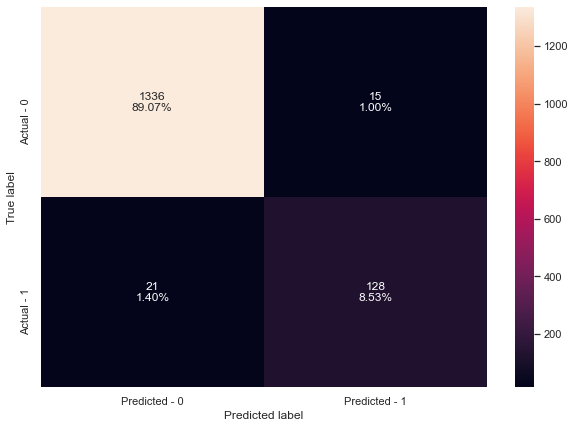

```python
make_confusion_matrix(dTree, y_test)  # Plotting confusion matrix on y_test
```

```python
# Recall on train and test
get_recall_score(dTree)
```

```
Recall on training set :  1.0
Recall on test set :  0.8590604026845637
```

#### Observation: The model was able to achieve 86% recall on the test set. This is not bad but we will try and see if it can be improved upon

## Visualizing the Decision Tree

```python
feature_names = list(
    X.columns
)  # saving the names of the independent features into a new list
print(
    feature_names
)  # To print out the names of all the independent features passed into the decision tree model
```

```
['Age', 'Experience', 'Income', 'Family', 'CCAvg', 'Education', 'Mortgage', 'Securities_Account', 'CD_Account', 'Online', 'CreditCard', 'county_Alameda ', 'county_Butte ', 'county_Contra Costa ', 'county_El Dorado ', 'county_Fresno ', 'county_Humboldt ', 'county_Imperial ', 'county_Kern ', 'county_L…
```

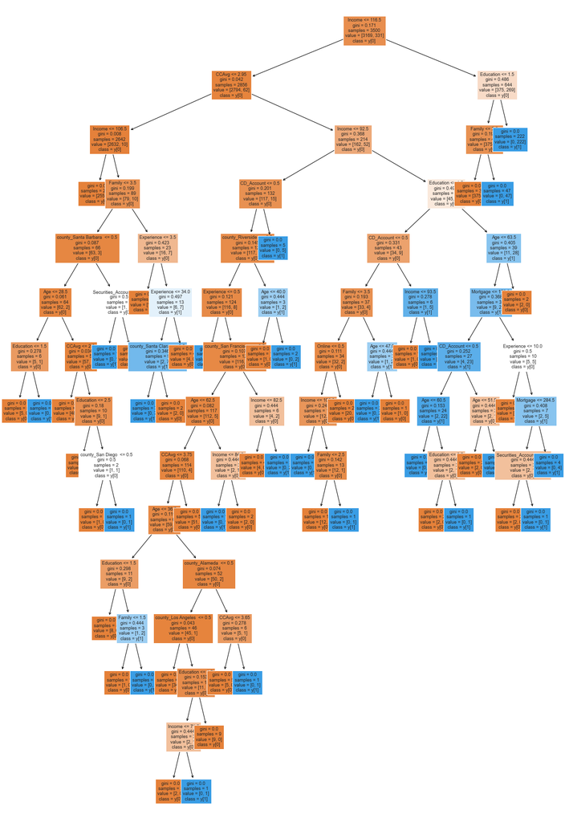

```python
# To plot the decision tree for visualisation
plt.figure(figsize=(20, 30))
out = tree.plot_tree(
    dTree,
    feature_names=feature_names,
    filled=True,
    fontsize=9,
    node_ids=False,
    class_names=True,
)

# below code will add arrows to the decision tree split if they are missing
for o in out:
    arrow = o.arrow_patch
    if arrow is not None:
        arrow.set_edgecolor("black")
        arrow.set_linewidth(1)
plt.show()
```

```python
# Text report showing the rules of a decision tree -

print(tree.export_text(dTree, feature_names=feature_names, show_weights=True))
```

```
|--- Income <= 116.50
|   |--- CCAvg <= 2.95
|   |   |--- Income <= 106.50
|   |   |   |--- weights: [2553.00, 0.00] class: 0
|   |   |--- Income >  106.50
|   |   |   |--- Family <= 3.50
|   |   |   |   |--- county_Santa Barbara  <= 0.50
|   |   |   |   |   |--- Age <= 28.50
|   |   |   |   |   |   |--- Education <= 1.50
|   |   |   |   |   |   |   |--- weights: [5.00, 0.00] class: 0
|   |   |   |   |   |   |--- Education >  1.50
|   |   |   |   |   |   |   |--- weights: [0.00, 1.00] class: 1
|   |   |   |   |   |--- Age >  28.50
|   |   |   |   |   |   |--- CCAvg <= 2.20
|   |   |   |   |   |   |   |--- weights: [48.00, 0.00] class: 0
|   |   |   |   |   |   |--- CCAvg >  2.20
|   |   |   |   |   |   |   |--- Education <= 2.50
|   |   |   |   |   |   |   |   |--- weights: [8.00, 0.00] class: 0
|   |   |   |   |   |   |   |--- Education >  2.50
|   |   |   |   |   |   |   |   |--- county_San Diego  <= 0.50
|   |   |   |   |   |   |   |   |   |--- weights: [1.00, 0.00] class: 0
|   |   |   |   |   |   |   |   |--- county_San Diego  >  0.50
|   |   |   |   |   |   |   |   |   |--- weights: [0.00, 1.00] class: 1
|   |   |   |   |--- county_Santa Barbara  >  0.50
|   |   |   |   |   |--- Securities_Account <= 0.50
|   |   |   |   |   |   |--- weights: [0.00, 1.00] class: 1
|   |   |   |   |   |--- Securities_Account >  0.50
|   |   |   |   |   |   |--- weights: [1.00, 0.00] class: 0
|   |   |   |--- Family >  3.50
|   |   |   |   |--- Experience <= 3.50
|   |   |   |   |   |--- weights: [10.00, 0.00] class: 0
|   |   |   |   |--- Experience >  3.50
|   |   |   |   |   |--- Experience <= 34.00
|   |   |   |   |   |   |--- county_Santa Clara  <= 0.50
|   |   |   |   |   |   |   |--- weights: [0.00, 7.00] class: 1
|   |   |   |   |   |   |--- county_Santa Clara  >  0.50
|   |   |   |   |   |   |   |--- weights: [2.00, 0.00] class: 0
|   |   |   |   |   |--- Experience >  34.00
|   |   |   |   |   |   |--- weights: [4.00, 0.00] class: 0
|   |--- CCAvg >  2.95
```

[output cut: 84 more lines]

```
|   |   |   |   |   |   |   |   |   |--- weights: [2.00, 0.00] class: 0
|   |   |   |   |   |   |   |   |--- Securities_Account >  0.50
|   |   |   |   |   |   |   |   |   |--- weights: [0.00, 1.00] class: 1
|   |   |   |   |   |   |   |--- Mortgage >  284.50
|   |   |   |   |   |   |   |   |--- weights: [0.00, 4.00] class: 1
|   |   |   |   |--- Age >  63.50
|   |   |   |   |   |--- weights: [2.00, 0.00] class: 0
|--- Income >  116.50
|   |--- Education <= 1.50
|   |   |--- Family <= 2.50
|   |   |   |--- weights: [375.00, 0.00] class: 0
|   |   |--- Family >  2.50
|   |   |   |--- weights: [0.00, 47.00] class: 1
|   |--- Education >  1.50
|   |   |--- weights: [0.00, 222.00] class: 1
```

#### Observation: This is a complex tree with the root node as Income<=116.5. We will try and reduce the complexity and see the performance of the new trees. However, we will check the importance of each independent variable first

```python
# importance of features in the tree building
print(
    pd.DataFrame(
        dTree.feature_importances_, columns=["Imp"], index=X_train.columns
    ).sort_values(by="Imp", ascending=False)
)
```

```
                              Imp
Education                0.411361
Income                   0.312134
Family                   0.151876
CCAvg                    0.041232
CD_Account               0.025711
Experience               0.017577
Age                      0.016087
Mortgage                 0.005557
county_Santa Clara       0.005190
Securities_Account       0.003893
county_Riverside         0.003544
county_San Diego         0.001668
county_San Francisco     0.001608
county_Santa Barbara     0.001422
Online                   0.000561
county_Alameda           0.000372
county_Los Angeles       0.000206
county_San Joaquin       0.000000
county_San Luis Obispo   0.000000
county_Ventura           0.000000
county_San Mateo         0.000000
county_Tuolumne          0.000000
county_Trinity           0.000000
county_Santa Cruz        0.000000
county_Shasta            0.000000
county_Siskiyou          0.000000
county_Solano            0.000000
county_San Bernardino    0.000000
county_Stanislaus        0.000000
county_Sonoma            0.000000
county_Monterey          0.000000
county_San Benito        0.000000
county_Sacramento        0.000000
CreditCard               0.000000
county_Butte             0.000000
county_Contra Costa      0.000000
county_El Dorado         0.000000
county_Fresno            0.000000
county_Humboldt          0.000000
county_Imperial          0.000000
county_Kern              0.000000
county_Lake              0.000000
county_Marin             0.000000
county_Mendocino         0.000000
county_Merced            0.000000
county_Napa              0.000000
county_Orange            0.000000
county_Placer            0.000000
county_Yolo              0.000000
```

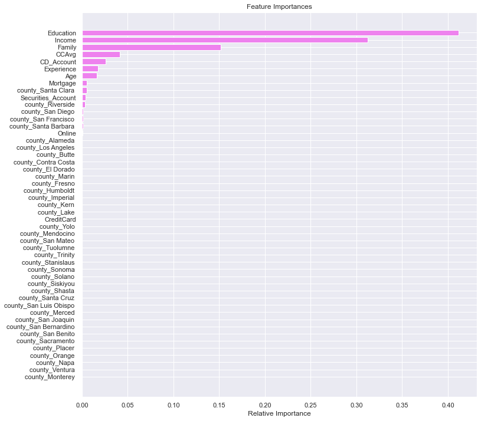

```python
# Let's plot a barchart showing the features importance
importances = dTree.feature_importances_
indices = np.argsort(importances)

plt.figure(figsize=(12, 12))
plt.title("Feature Importances")
plt.barh(range(len(indices)), importances[indices], color="violet", align="center")
plt.yticks(range(len(indices)), [feature_names[i] for i in indices])
plt.xlabel("Relative Importance")
plt.show()
```

- According to the decision tree model, Education is the most important variable for predicting the Asset customer. This is followed by Income and Family size of the customer.

**As said earlier, the tree above is very complex, such a tree often overfits.**

- Let's try Limiting the max_depth of tree to 3

```python
# To limit the maximum depth of the tree to 3
dTree1 = DecisionTreeClassifier(criterion="gini", max_depth=3, random_state=1)
dTree1.fit(X_train, y_train)
```

```
DecisionTreeClassifier(ccp_alpha=0.0, class_weight=None, criterion='gini',
                       max_depth=3, max_features=None, max_leaf_nodes=None,
                       min_impurity_decrease=0.0, min_impurity_split=None,
                       min_samples_leaf=1, min_samples_split=2,
                       min_weight_fraction_leaf=0.0, presort='deprecated',
                       random_state=1, splitter='best')
```

## Confusion Matrix - decision tree with depth restricted to 3

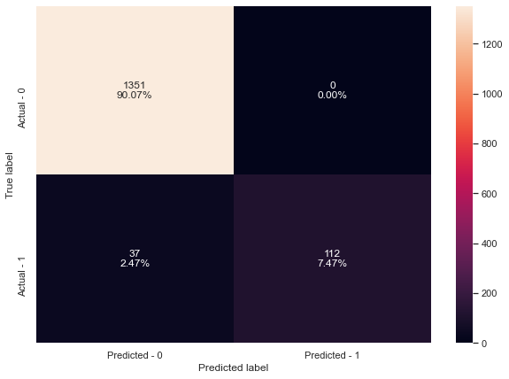

```python
# Let's create the confusion matrix of the new model with depth restricted to 3
make_confusion_matrix(dTree1, y_test)
```

#### Observation: The new model with depth restricted to 3 was able to reduce false positives(that is, non asset customers predicted as asset customers) to zero but the false negatives was increased to 2.47% from the initial 1.40%. This will definitely affect the recall score of the model negatively

```python
# Let's check the model performance
# Accuracy on train and test
print("Accuracy on training set : ", dTree1.score(X_train, y_train))
print("Accuracy on test set : ", dTree1.score(X_test, y_test))
# Recall on train and test
get_recall_score(dTree1)
```

```
Accuracy on training set :  0.9822857142857143
Accuracy on test set :  0.9753333333333334
Recall on training set :  0.8126888217522659
Recall on test set :  0.7516778523489933
```

- Recall on training set has reduced from 1 to 0.81 but this is an improvement because now the model is not overfitting and we have a generalized model.

### Visualizing the Decision Tree

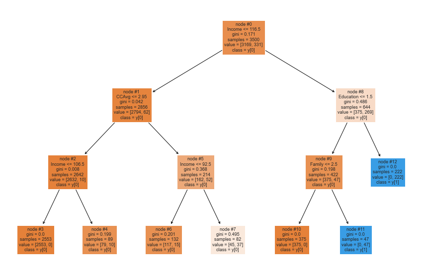

```python
# Now, let's visualise the decision tree with maximum depth 3
plt.figure(figsize=(15, 10))

out = tree.plot_tree(
    dTree1,
    feature_names=feature_names,
    filled=True,
    fontsize=9,
    node_ids=True,
    class_names=True,
)
for o in out:
    arrow = o.arrow_patch
    if arrow is not None:
        arrow.set_edgecolor("black")
        arrow.set_linewidth(1)
plt.show()
```

```python
# Text report showing the rules of a decision tree -

print(tree.export_text(dTree1, feature_names=feature_names, show_weights=True))
```

```
|--- Income <= 116.50
|   |--- CCAvg <= 2.95
|   |   |--- Income <= 106.50
|   |   |   |--- weights: [2553.00, 0.00] class: 0
|   |   |--- Income >  106.50
|   |   |   |--- weights: [79.00, 10.00] class: 0
|   |--- CCAvg >  2.95
|   |   |--- Income <= 92.50
|   |   |   |--- weights: [117.00, 15.00] class: 0
|   |   |--- Income >  92.50
|   |   |   |--- weights: [45.00, 37.00] class: 0
|--- Income >  116.50
|   |--- Education <= 1.50
|   |   |--- Family <= 2.50
|   |   |   |--- weights: [375.00, 0.00] class: 0
|   |   |--- Family >  2.50
|   |   |   |--- weights: [0.00, 47.00] class: 1
|   |--- Education >  1.50
|   |   |--- weights: [0.00, 222.00] class: 1
```

#### Observation: This new tree is a less complex when compared with the first. However, its performance based on its recall score on the test set is lower. Let's see the important features based on this model

```python
# importance of features in the tree building
print(
    pd.DataFrame(
        dTree1.feature_importances_, columns=["Imp"], index=X_train.columns
    ).sort_values(by="Imp", ascending=False)
)
```

```
                              Imp
Education                0.446593
Income                   0.346997
Family                   0.162372
CCAvg                    0.044038
Age                      0.000000
county_Santa Clara       0.000000
county_Sacramento        0.000000
county_San Benito        0.000000
county_San Bernardino    0.000000
county_San Diego         0.000000
county_San Francisco     0.000000
county_San Joaquin       0.000000
county_San Luis Obispo   0.000000
county_San Mateo         0.000000
county_Santa Barbara     0.000000
county_Shasta            0.000000
county_Santa Cruz        0.000000
county_Placer            0.000000
county_Siskiyou          0.000000
county_Solano            0.000000
county_Sonoma            0.000000
county_Stanislaus        0.000000
county_Trinity           0.000000
county_Tuolumne          0.000000
county_Ventura           0.000000
county_Riverside         0.000000
county_Monterey          0.000000
county_Orange            0.000000
county_Napa              0.000000
Mortgage                 0.000000
Securities_Account       0.000000
CD_Account               0.000000
Online                   0.000000
CreditCard               0.000000
county_Alameda           0.000000
county_Butte             0.000000
county_Contra Costa      0.000000
county_El Dorado         0.000000
county_Fresno            0.000000
county_Humboldt          0.000000
county_Imperial          0.000000
county_Kern              0.000000
county_Lake              0.000000
county_Los Angeles       0.000000
county_Marin             0.000000
county_Mendocino         0.000000
county_Merced            0.000000
Experience               0.000000
county_Yolo              0.000000
```

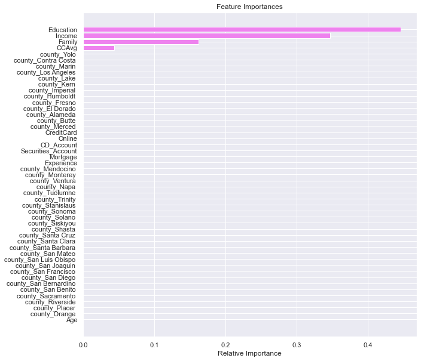

```python
# Let's plot the bar chart showing the features importance
importances = dTree1.feature_importances_
indices = np.argsort(importances)

plt.figure(figsize=(10, 10))
plt.title("Feature Importances")
plt.barh(range(len(indices)), importances[indices], color="violet", align="center")
plt.yticks(range(len(indices)), [feature_names[i] for i in indices])
plt.xlabel("Relative Importance")
plt.show()
```

- Education, Income and Family still top the chart of important features like the previous model. However the shortcoming of this model is its performance on the test set.
- That's why we will go for pre pruning using grid search, maybe setting max_depth to 3 is not good enough
- A very low depth like that often do not give good model as it will underfit the data
- Let's see how to find the best values

### Using GridSearch for Hyperparameter tuning of our tree model

```python
# Let's choose the type of classifier.
estimator = DecisionTreeClassifier(random_state=1)

# Grid of parameters to choose from
parameters = {
    "max_depth": np.arange(1, 14),
    "min_samples_leaf": [1, 2, 5, 7, 10, 15, 20],
    "max_leaf_nodes": [2, 3, 5, 10],
    "min_impurity_decrease": [0.001, 0.01, 0.1],
}

# Type of scoring used to compare parameter combinations
acc_scorer = metrics.make_scorer(metrics.recall_score)

# Run the grid search
grid_obj = GridSearchCV(estimator, parameters, scoring=acc_scorer, cv=5)
grid_obj = grid_obj.fit(X_train, y_train)

# Set the classifier to the best combination of parameters
estimator = grid_obj.best_estimator_

# Fit the best algorithm to the data.
estimator.fit(X_train, y_train)
```

```
DecisionTreeClassifier(ccp_alpha=0.0, class_weight=None, criterion='gini',
                       max_depth=5, max_features=None, max_leaf_nodes=10,
                       min_impurity_decrease=0.001, min_impurity_split=None,
                       min_samples_leaf=1, min_samples_split=2,
                       min_weight_fraction_leaf=0.0, presort='deprecated',
                       random_state=1, splitter='best')
```

## Confusion Matrix - decision tree with tuned hyperparameters

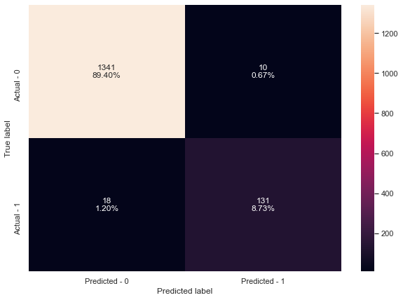

```python
# Let's make a conftusion matrix of the new model with tuned hyperparameters
make_confusion_matrix(estimator, y_test)
```

```python
# Accuracy on train and test
print("Accuracy on training set : ", estimator.score(X_train, y_train))
print("Accuracy on test set : ", estimator.score(X_test, y_test))
# Recall on train and test
get_recall_score(estimator)
```

```
Accuracy on training set :  0.9897142857142858
Accuracy on test set :  0.9813333333333333
Recall on training set :  0.9274924471299094
Recall on test set :  0.8791946308724832
```

- Recall on both train and test set have improved after hyperparameter tuning to 0.93 and 0.88 respectively. This shows better performance than randomly limiting a hyperparameter. However, we will consider some post-pruning methods and choose the one that gives the best performance on our test data. This means that we will eventually stick to the model that performs best in identifying the potential asset customers

## Visualizing the Decision Tree

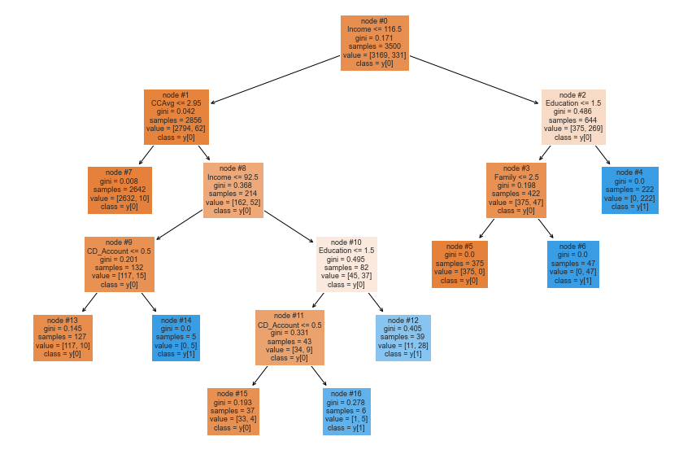

```python
#Let's see the new decision tree
plt.figure(figsize=(15,10))

out=tree.plot_tree(estimator,feature_names=feature_names,filled=True,fontsize=9,node_ids=True,class_names=True)
for o in out:
    arrow = o.arrow_patch
    if arrow is not None:
        arrow.set_edgecolor('black')
        arrow.set_linewidth(1)
plt.show()
```

```python
# Text report showing the rules of a decision tree -

print(tree.export_text(estimator, feature_names=feature_names, show_weights=True))
```

```
|--- Income <= 116.50
|   |--- CCAvg <= 2.95
|   |   |--- weights: [2632.00, 10.00] class: 0
|   |--- CCAvg >  2.95
|   |   |--- Income <= 92.50
|   |   |   |--- CD_Account <= 0.50
|   |   |   |   |--- weights: [117.00, 10.00] class: 0
|   |   |   |--- CD_Account >  0.50
|   |   |   |   |--- weights: [0.00, 5.00] class: 1
|   |   |--- Income >  92.50
|   |   |   |--- Education <= 1.50
|   |   |   |   |--- CD_Account <= 0.50
|   |   |   |   |   |--- weights: [33.00, 4.00] class: 0
|   |   |   |   |--- CD_Account >  0.50
|   |   |   |   |   |--- weights: [1.00, 5.00] class: 1
|   |   |   |--- Education >  1.50
|   |   |   |   |--- weights: [11.00, 28.00] class: 1
|--- Income >  116.50
|   |--- Education <= 1.50
|   |   |--- Family <= 2.50
|   |   |   |--- weights: [375.00, 0.00] class: 0
|   |   |--- Family >  2.50
|   |   |   |--- weights: [0.00, 47.00] class: 1
|   |--- Education >  1.50
|   |   |--- weights: [0.00, 222.00] class: 1
```

#### Observation: This is a better tree than the one with maximum depth of 3. It has its root node as Income <= 116.50

```python
# Let's check the important features

print(
    pd.DataFrame(
        estimator.feature_importances_, columns=["Imp"], index=X_train.columns
    ).sort_values(by="Imp", ascending=False)
)

# Here we will see that importance of features has increased
```

```
                              Imp
Education                0.447999
Income                   0.328713
Family                   0.155711
CCAvg                    0.042231
CD_Account               0.025345
Age                      0.000000
county_Santa Clara       0.000000
county_Sacramento        0.000000
county_San Benito        0.000000
county_San Bernardino    0.000000
county_San Diego         0.000000
county_San Francisco     0.000000
county_San Joaquin       0.000000
county_San Luis Obispo   0.000000
county_San Mateo         0.000000
county_Santa Barbara     0.000000
county_Siskiyou          0.000000
county_Santa Cruz        0.000000
county_Shasta            0.000000
county_Placer            0.000000
county_Solano            0.000000
county_Sonoma            0.000000
county_Stanislaus        0.000000
county_Trinity           0.000000
county_Tuolumne          0.000000
county_Ventura           0.000000
county_Riverside         0.000000
county_Monterey          0.000000
county_Orange            0.000000
county_Fresno            0.000000
Mortgage                 0.000000
Securities_Account       0.000000
Online                   0.000000
CreditCard               0.000000
county_Alameda           0.000000
county_Butte             0.000000
county_Contra Costa      0.000000
county_El Dorado         0.000000
county_Humboldt          0.000000
county_Napa              0.000000
county_Imperial          0.000000
county_Kern              0.000000
county_Lake              0.000000
county_Los Angeles       0.000000
county_Marin             0.000000
county_Mendocino         0.000000
county_Merced            0.000000
Experience               0.000000
county_Yolo              0.000000
```

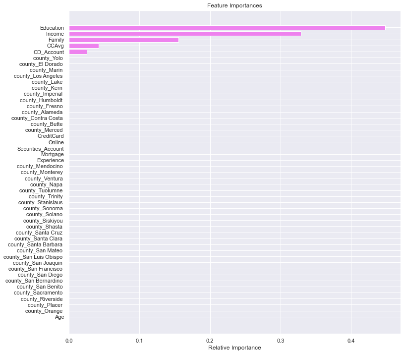

```python
# Let's plot the barchart of the feature importance
importances = estimator.feature_importances_
indices = np.argsort(importances)

plt.figure(figsize=(12, 12))
plt.title("Feature Importances")
plt.barh(range(len(indices)), importances[indices], color="violet", align="center")
plt.yticks(range(len(indices)), [feature_names[i] for i in indices])
plt.xlabel("Relative Importance")
plt.show()
```

## Cost Complexity Pruning Method

```python
# Let's fit a model using the cost complexity pruning method
clf = DecisionTreeClassifier(random_state=1)
path = clf.cost_complexity_pruning_path(X_train, y_train)
ccp_alphas, impurities = path.ccp_alphas, path.impurities
```

```python
pd.DataFrame(path)  # Checking the ccp_alphas impurities level
```

|  | ccp_alphas | impurities |
| --- | --- | --- |
| 0 | 0.000000 | 0.000000 |
| 1 | 0.000186 | 0.000559 |
| 2 | 0.000187 | 0.001121 |
| 3 | 0.000269 | 0.002195 |
| 4 | 0.000270 | 0.002735 |
| 5 | 0.000273 | 0.004371 |
| 6 | 0.000359 | 0.005447 |
| 7 | 0.000381 | 0.005828 |
| 8 | 0.000381 | 0.006209 |
| 9 | 0.000381 | 0.006590 |
| 10 | 0.000381 | 0.006971 |
| 11 | 0.000381 | 0.007352 |
| 12 | 0.000435 | 0.007787 |
| 13 | 0.000476 | 0.008263 |
| 14 | 0.000514 | 0.009805 |
| 15 | 0.000578 | 0.012118 |
| 16 | 0.000582 | 0.012701 |
| 17 | 0.000607 | 0.013307 |
| 18 | 0.000621 | 0.013928 |
| 19 | 0.000811 | 0.017985 |
| 20 | 0.001552 | 0.019536 |
| 21 | 0.002333 | 0.021869 |
| 22 | 0.003024 | 0.024893 |
| 23 | 0.003294 | 0.028187 |
| 24 | 0.006473 | 0.034659 |
| 25 | 0.023866 | 0.058525 |
| 26 | 0.056365 | 0.171255 |

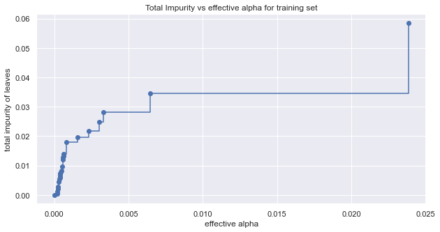

```python
# Let's plot the graph of the impurities and the ccp_alphas and the impurities
fig, ax = plt.subplots(figsize=(10, 5))
ax.plot(ccp_alphas[:-1], impurities[:-1], marker="o", drawstyle="steps-post")
ax.set_xlabel("effective alpha")
ax.set_ylabel("total impurity of leaves")
ax.set_title("Total Impurity vs effective alpha for training set")
plt.show()
```

Next, we train a decision tree using the effective alphas. The last value in `ccp_alphas` is the alpha value that prunes the whole tree, leaving the tree, `clfs[-1]`, with one node.

```python
# fitting the model with the ccp_alphas
clfs = []
for ccp_alpha in ccp_alphas:
    clf = DecisionTreeClassifier(random_state=1, ccp_alpha=ccp_alpha)
    clf.fit(X_train, y_train)
    clfs.append(clf)
print(
    "Number of nodes in the last tree is: {} with ccp_alpha: {}".format(
        clfs[-1].tree_.node_count, ccp_alphas[-1]
    )
)
```

```
Number of nodes in the last tree is: 1 with ccp_alpha: 0.056364969335601575
```

For the remainder, we remove the last element in `clfs` and `ccp_alphas`, because it is the trivial tree with only one node. Here we show that the number of nodes and tree depth decreases as alpha increases.

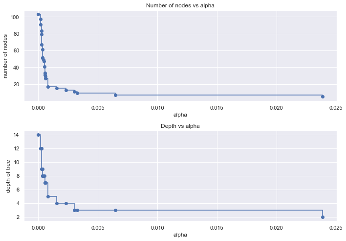

```python
# Plotting the new tree with cost complexity pruning using ccp_alpha


clfs = clfs[:-1]
ccp_alphas = ccp_alphas[:-1]

node_counts = [clf.tree_.node_count for clf in clfs]
depth = [clf.tree_.max_depth for clf in clfs]
fig, ax = plt.subplots(2, 1, figsize=(10, 7))
ax[0].plot(ccp_alphas, node_counts, marker="o", drawstyle="steps-post")
ax[0].set_xlabel("alpha")
ax[0].set_ylabel("number of nodes")
ax[0].set_title("Number of nodes vs alpha")
ax[1].plot(ccp_alphas, depth, marker="o", drawstyle="steps-post")
ax[1].set_xlabel("alpha")
ax[1].set_ylabel("depth of tree")
ax[1].set_title("Depth vs alpha")
fig.tight_layout()
```

```python
train_scores = [
    clf.score(X_train, y_train) for clf in clfs
]  # To check accuracy on train set
test_scores = [
    clf.score(X_test, y_test) for clf in clfs
]  # to check accuracy on test set
```

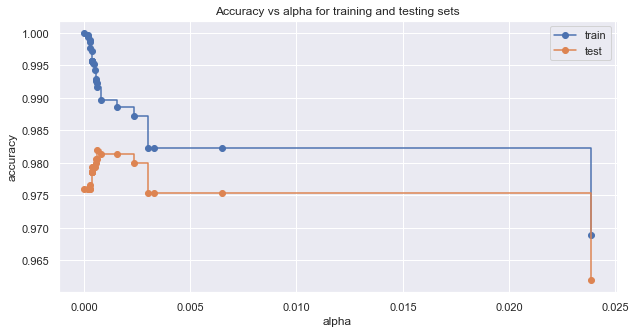

```python
# To plot graph showing the accuracy on both train and test sets
fig, ax = plt.subplots(figsize=(10, 5))
ax.set_xlabel("alpha")
ax.set_ylabel("accuracy")
ax.set_title("Accuracy vs alpha for training and testing sets")
ax.plot(ccp_alphas, train_scores, marker="o", label="train", drawstyle="steps-post")
ax.plot(ccp_alphas, test_scores, marker="o", label="test", drawstyle="steps-post")
ax.legend()
plt.show()
```

```python
# Let's fit the best model and check its accuracy and recall
index_best_model = np.argmax(test_scores)
best_model = clfs[index_best_model]
print(best_model)
print("Training accuracy of best model: ", best_model.score(X_train, y_train))
print("Test accuracy of best model: ", best_model.score(X_test, y_test))
```

```
DecisionTreeClassifier(ccp_alpha=0.0006209286209286216, class_weight=None,
                       criterion='gini', max_depth=None, max_features=None,
                       max_leaf_nodes=None, min_impurity_decrease=0.0,
                       min_impurity_split=None, min_samples_leaf=1,
                       min_samples_split=2, min_weight_fraction_leaf=0.0,
                       presort='deprecated', random_state=1, splitter='best')
Training accuracy of best model:  0.9917142857142857
Test accuracy of best model:  0.982
```

#### We got 98% as the accuracy for test set using the best model gotten through cost complexity pruning method. However, since accuracy isn't the right metric for our data we would want high recall. So let's check the recall of the model

```python
# To check recall on train set
recall_train = []
for clf in clfs:
    pred_train3 = clf.predict(X_train)
    values_train = metrics.recall_score(y_train, pred_train3)
    recall_train.append(values_train)
```

```python
# To check recall on test set
recall_test = []
for clf in clfs:
    pred_test3 = clf.predict(X_test)
    values_test = metrics.recall_score(y_test, pred_test3)
    recall_test.append(values_test)
```

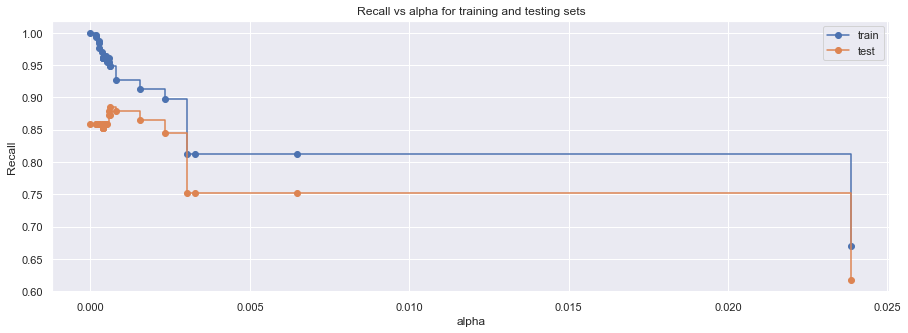

```python
# To plot the graph of recall on both train and test sets
fig, ax = plt.subplots(figsize=(15, 5))
ax.set_xlabel("alpha")
ax.set_ylabel("Recall")
ax.set_title("Recall vs alpha for training and testing sets")
ax.plot(ccp_alphas, recall_train, marker="o", label="train", drawstyle="steps-post")
ax.plot(ccp_alphas, recall_test, marker="o", label="test", drawstyle="steps-post")
ax.legend()
plt.show()
```

```python
# creating the model where we get highest train and test recall
index_best_model = np.argmax(recall_test)
best_model = clfs[index_best_model]
print(best_model)
```

```
DecisionTreeClassifier(ccp_alpha=0.0006209286209286216, class_weight=None,
                       criterion='gini', max_depth=None, max_features=None,
                       max_leaf_nodes=None, min_impurity_decrease=0.0,
                       min_impurity_split=None, min_samples_leaf=1,
                       min_samples_split=2, min_weight_fraction_leaf=0.0,
                       presort='deprecated', random_state=1, splitter='best')
```

## Confusion Matrix - post-pruned decision tree

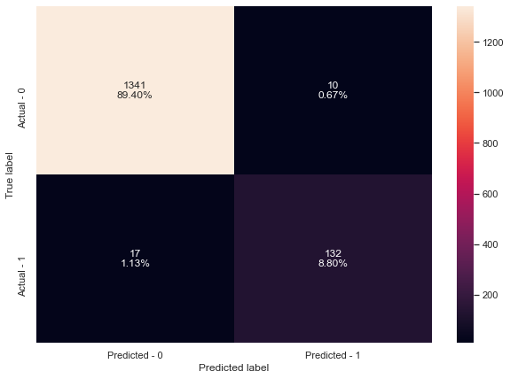

```python
make_confusion_matrix(
    best_model, y_test
)  # to make the confusion matrix of the post-pruned decision tree
```

```python
# Recall on train and test
get_recall_score(best_model)
```

```
Recall on training set :  0.9486404833836858
Recall on test set :  0.8859060402684564
```

## Visualizing the Decision Tree

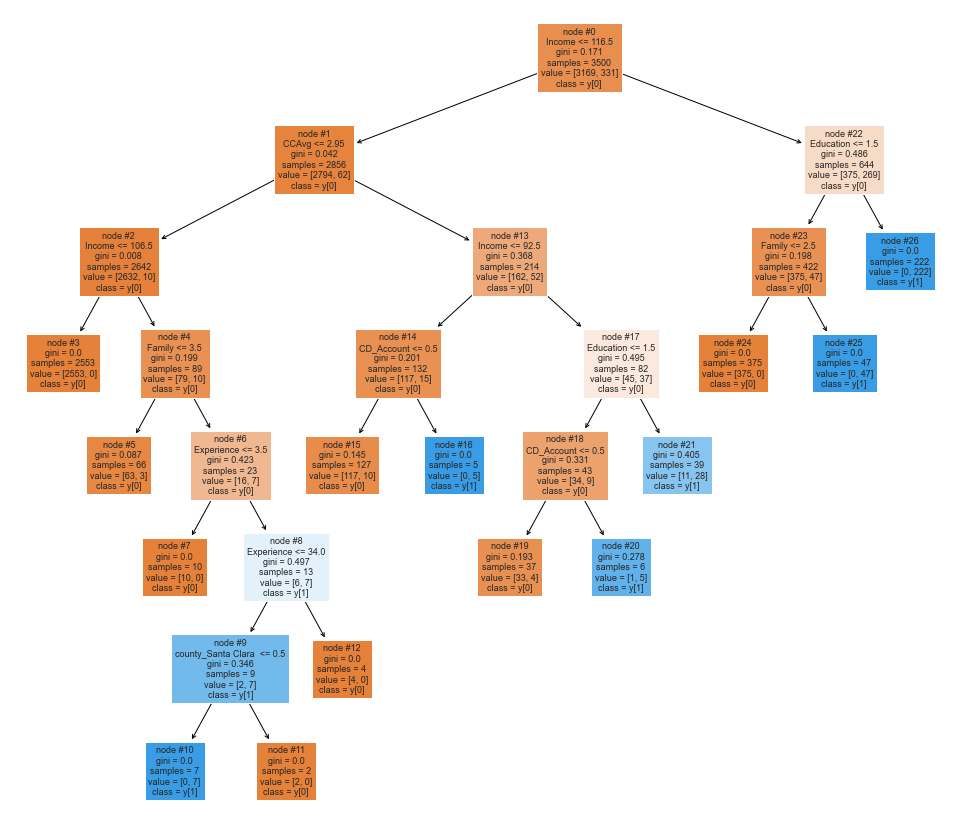

```python
# Let's visualise the decision tree
plt.figure(figsize=(17, 15))

out = tree.plot_tree(
    best_model,
    feature_names=feature_names,
    filled=True,
    fontsize=9,
    node_ids=True,
    class_names=True,
)
for o in out:
    arrow = o.arrow_patch
    if arrow is not None:
        arrow.set_edgecolor("black")
        arrow.set_linewidth(1)
plt.show()
```

```python
# Text report showing the rules of a decision tree -

print(tree.export_text(best_model, feature_names=feature_names, show_weights=True))
```

```
|--- Income <= 116.50
|   |--- CCAvg <= 2.95
|   |   |--- Income <= 106.50
|   |   |   |--- weights: [2553.00, 0.00] class: 0
|   |   |--- Income >  106.50
|   |   |   |--- Family <= 3.50
|   |   |   |   |--- weights: [63.00, 3.00] class: 0
|   |   |   |--- Family >  3.50
|   |   |   |   |--- Experience <= 3.50
|   |   |   |   |   |--- weights: [10.00, 0.00] class: 0
|   |   |   |   |--- Experience >  3.50
|   |   |   |   |   |--- Experience <= 34.00
|   |   |   |   |   |   |--- county_Santa Clara  <= 0.50
|   |   |   |   |   |   |   |--- weights: [0.00, 7.00] class: 1
|   |   |   |   |   |   |--- county_Santa Clara  >  0.50
|   |   |   |   |   |   |   |--- weights: [2.00, 0.00] class: 0
|   |   |   |   |   |--- Experience >  34.00
|   |   |   |   |   |   |--- weights: [4.00, 0.00] class: 0
|   |--- CCAvg >  2.95
|   |   |--- Income <= 92.50
|   |   |   |--- CD_Account <= 0.50
|   |   |   |   |--- weights: [117.00, 10.00] class: 0
|   |   |   |--- CD_Account >  0.50
|   |   |   |   |--- weights: [0.00, 5.00] class: 1
|   |   |--- Income >  92.50
|   |   |   |--- Education <= 1.50
|   |   |   |   |--- CD_Account <= 0.50
|   |   |   |   |   |--- weights: [33.00, 4.00] class: 0
|   |   |   |   |--- CD_Account >  0.50
|   |   |   |   |   |--- weights: [1.00, 5.00] class: 1
|   |   |   |--- Education >  1.50
|   |   |   |   |--- weights: [11.00, 28.00] class: 1
|--- Income >  116.50
|   |--- Education <= 1.50
|   |   |--- Family <= 2.50
|   |   |   |--- weights: [375.00, 0.00] class: 0
|   |   |--- Family >  2.50
|   |   |   |--- weights: [0.00, 47.00] class: 1
|   |--- Education >  1.50
|   |   |--- weights: [0.00, 222.00] class: 1
```

```python
# checking the importance of features in the tree building
print(
    pd.DataFrame(
        best_model.feature_importances_, columns=["Imp"], index=X_train.columns
    ).sort_values(by="Imp", ascending=False)
)
```

```
                              Imp
Education                0.436448
Income                   0.324182
Family                   0.155849
CCAvg                    0.041142
CD_Account               0.024692
Experience               0.012037
county_Santa Clara       0.005650
Age                      0.000000
county_San Benito        0.000000
county_San Bernardino    0.000000
county_San Diego         0.000000
county_San Francisco     0.000000
county_San Joaquin       0.000000
county_San Luis Obispo   0.000000
county_San Mateo         0.000000
county_Santa Barbara     0.000000
county_Siskiyou          0.000000
county_Santa Cruz        0.000000
county_Shasta            0.000000
county_Riverside         0.000000
county_Solano            0.000000
county_Sonoma            0.000000
county_Stanislaus        0.000000
county_Trinity           0.000000
county_Tuolumne          0.000000
county_Ventura           0.000000
county_Sacramento        0.000000
county_Monterey          0.000000
county_Placer            0.000000
county_Fresno            0.000000
Mortgage                 0.000000
Securities_Account       0.000000
Online                   0.000000
CreditCard               0.000000
county_Alameda           0.000000
county_Butte             0.000000
county_Contra Costa      0.000000
county_El Dorado         0.000000
county_Humboldt          0.000000
county_Orange            0.000000
county_Imperial          0.000000
county_Kern              0.000000
county_Lake              0.000000
county_Los Angeles       0.000000
county_Marin             0.000000
county_Mendocino         0.000000
county_Merced            0.000000
county_Napa              0.000000
county_Yolo              0.000000
```

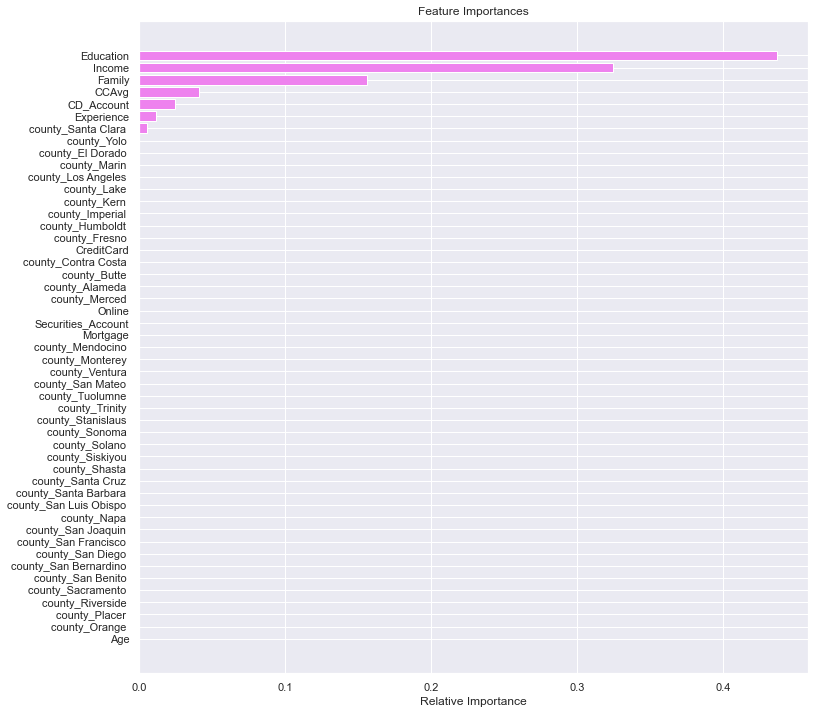

```python
# plotting the graph of feature importances
importances = best_model.feature_importances_
indices = np.argsort(importances)

plt.figure(figsize=(12, 12))
plt.title("Feature Importances")
plt.barh(range(len(indices)), importances[indices], color="violet", align="center")
plt.yticks(range(len(indices)), [feature_names[i] for i in indices])
plt.xlabel("Relative Importance")
plt.show()
```

- Education, Income and Family size of customers are still the most important features determining an asset customer

## Comparing all the decision tree models

```python
# Now let's compare the models and choose the best for projective objective
comparison_frame = pd.DataFrame(
    {
        "Model": [
            "Initial decision tree model",
            "Decision tree with restricted maximum depth",
            "Decision treee with hyperparameter tuning",
            "Decision tree with post-pruning",
        ],
        "Train_Recall": [1, 0.81, 0.93, 0.95],
        "Test_Recall": [0.86, 0.75, 0.88, 0.89],
    }
)
comparison_frame
```

|  | Model | Train_Recall | Test_Recall |
| --- | --- | --- | --- |
| 0 | Initial decision tree model | 1.00 | 0.86 |
| 1 | Decision tree with restricted maximum depth | 0.81 | 0.75 |
| 2 | Decision treee with hyperparameter tuning | 0.93 | 0.88 |
| 3 | Decision tree with post-pruning | 0.95 | 0.89 |

**Decision tree with post-pruning is giving the highest recall of 0.89 on test set and we will be going with this model**

## Conclusion:

#### 2. Education, Income and Family Size are the most significant variables for identifying a personal loan customer

## Summary of Insights and Recommendations

#### 1. Customers with family size 3 and 4 have higher conversion rate to asset customers than others. Marketing campaign on loan should therefore be focused on this class of customers

#### 2. Customers with at least Graduate Education have higher conversion rate to asset customers. This must be considered in the next loan campaign of the bank to have higher success rate

#### 3. Customers without securities account are 7 times more likely become asset customer than those without securities account. All Life Bank marketing team needs to focus on these customers

#### 4. Customers with internet banking facilities have slightly higher conversion rate to asset customers than others. However, I will advise the marketing team ensures their next loan campaign reaches all customers whether they have internet banking facilities or not. They can create a personal loan product accessible on the bank's internet banking platform(this will attract internet banking customers) and other platforms accessbile to non-internet banking customers

#### 5. Customers without other bank's credit card take personal loan more in All Life Bank than others with other bank's credit card. However, conversion to asset customer rates for customers with and without other bank's credit card are not significantly different. Marketing team should therefore take their campaigns to all customers

#### 6. Customers from Los Angeles, Santa Clara, San Diego and Alameda constitute over 59% of all the bank's personal loan customers. The marketing team should therefore focus their marketing campaigns to these counties as they also constitute 55% of their total customer base. However, worthy of mention is that customers from Sonoma county has the highest conversion to loan customer rate as approximately 3 in every 10 customers from that county are likely to take loan. Marketing effort to drive onboarding more customers from Sonoma County is hereby recommended.